[figure not shown]

[figure not shown]

# Outbreaks

### **Outbreak Likelihood - Western U.S.**

**Slightly elevated**

### **Outbreak Likelihood - Eastern U.S.**

**Slightly elevated**

### **Preseason Salmonellosis Outbreak Likelihood Synopsis**

There is a slightly elevated likelihood of a large outbreak in both the Western and Eastern United States (see colored regions below) this year, due to the moderate likelihood of Pine Siskin irruptions in both regions. Our prediction for the 2025-2026 winter is that Pine Siskins are more likely to irrupt in the West compared to the East. Click [here](https://bentonelli.github.io/Irr_Salm_Forecast.html#irruptions) or on the “Irruptions” tab above to see predictions for the Pine Siskin and seven other irruptive species.

### **Live Tracking: See below!**

The map below shows the location of healthy/sick Pine Siskins based on images submitted to eBird during this winter season. Grey dots show locations where healthy Pine Siskins were reported, yellow dots show the location of *potentially* sick birds, and red dots show the locations of clearly ill individuals. Map maintained by Nayantara Biswas.

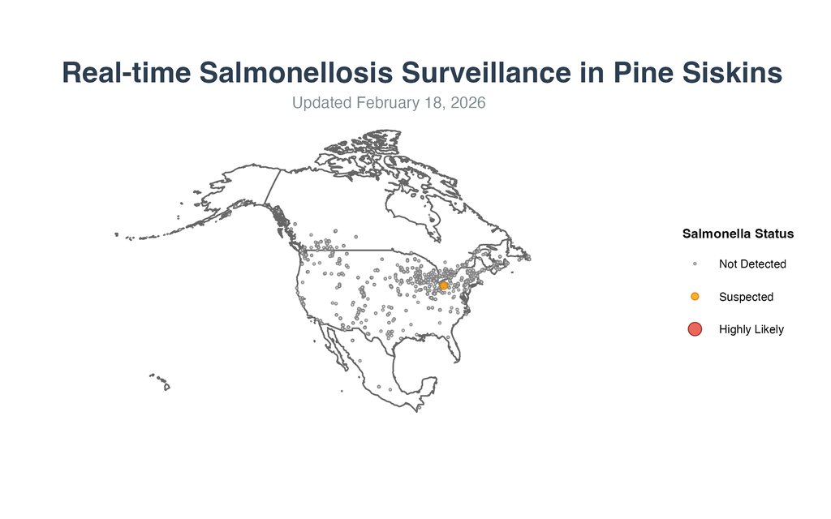

# Irruptions

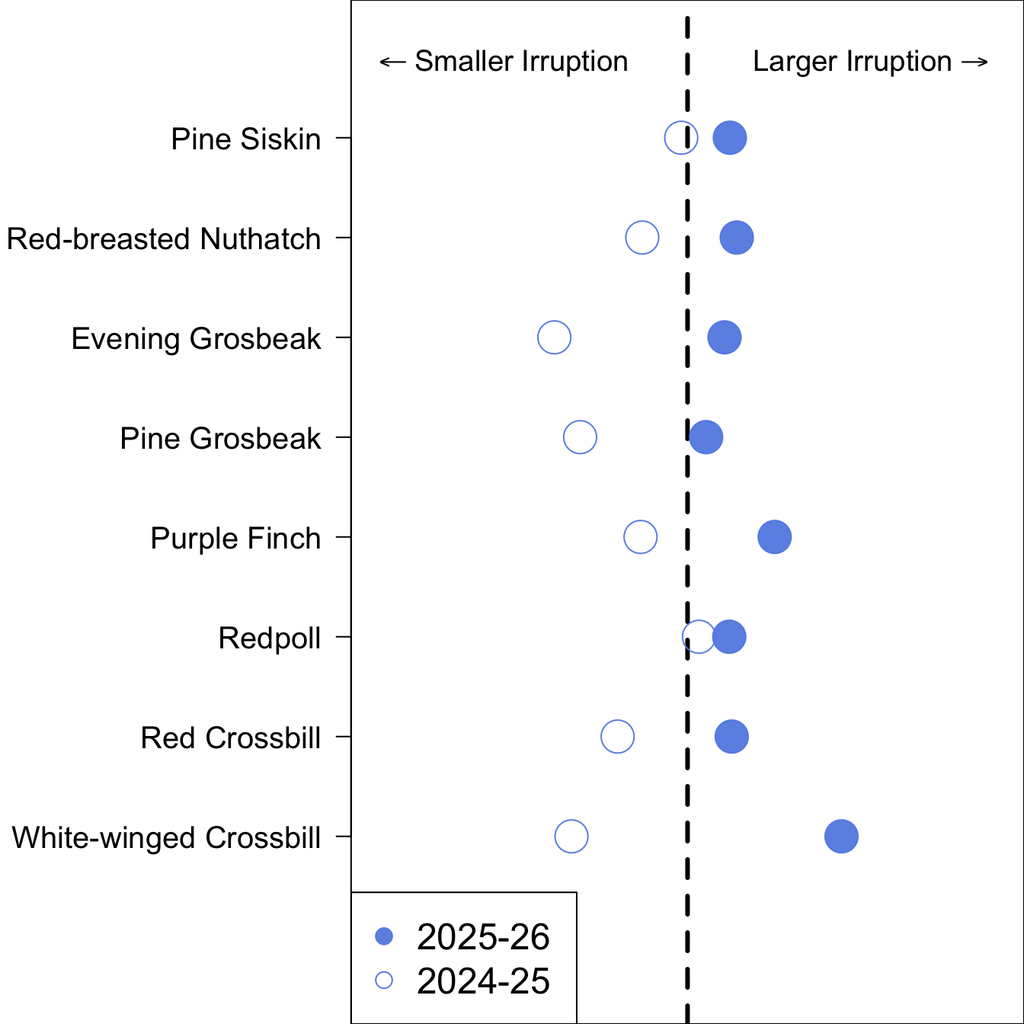

### **Western Irruption Forecast**

Irruptions are predicted to be above average for all eight species in the Western region this year (filled circles).

We predict a lower than normal predicted cone crop in the West this summer/fall.

Relatively weak irruptions were observed across all species last year (open circles).

Of all species, White-winged Crossbill is predicted to exhibit the largest irruption.

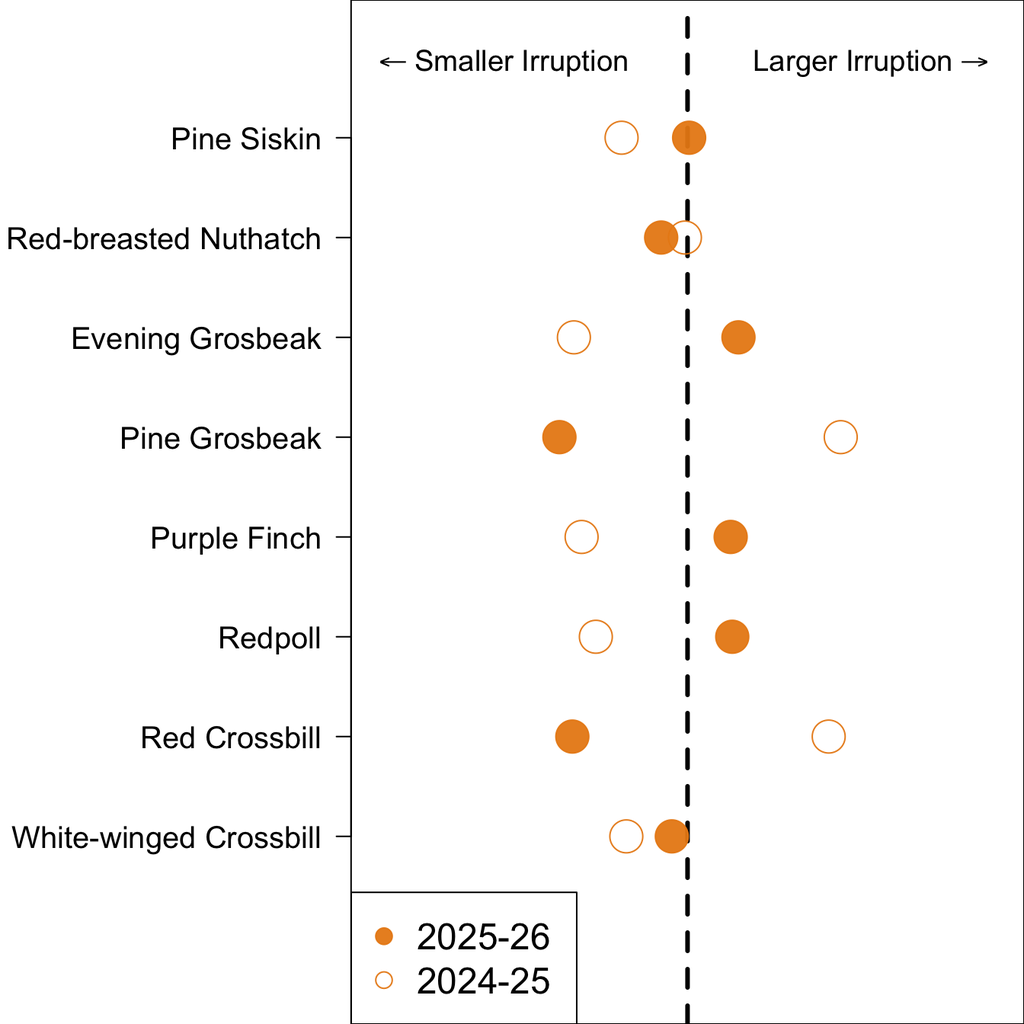

### **Eastern Irruption Forecast**

Irruptions are predicted to vary in strength across the eight species in the Eastern region this year (filled circles).

Cone crops are predicted to be around average across the region this year.

Red Crossbills and Pine Grosbeaks exhibited large irruptions last year (open circles), and as a result, our model predicts relatively weak/no irruptions for these species.